# Chapter 4 - Doing Data Analysis with the Multilevel Model for Change

# Example: Changes in Adolescent Alcohol Use

Load the data.

```r
library(tidyverse)
alcohol1_pp <- read_csv("data/alcohol1_pp.csv")
head(alcohol1_pp)
```

| id | age | coa | male | age_14 | alcuse | peer | cpeer | ccoa |
| --- | --- | --- | --- | --- | --- | --- | --- | --- |
| 1 | 14 | 1 | 0 | 0 | 1.732051 | 1.2649111 | 0.2469111 | 0.549 |
| 1 | 15 | 1 | 0 | 1 | 2.000000 | 1.2649111 | 0.2469111 | 0.549 |
| 1 | 16 | 1 | 0 | 2 | 2.000000 | 1.2649111 | 0.2469111 | 0.549 |
| 2 | 14 | 1 | 1 | 0 | 0.000000 | 0.8944272 | -0.1235728 | 0.549 |
| 2 | 15 | 1 | 1 | 1 | 0.000000 | 0.8944272 | -0.1235728 | 0.549 |
| 2 | 16 | 1 | 1 | 2 | 1.000000 | 0.8944272 | -0.1235728 | 0.549 |

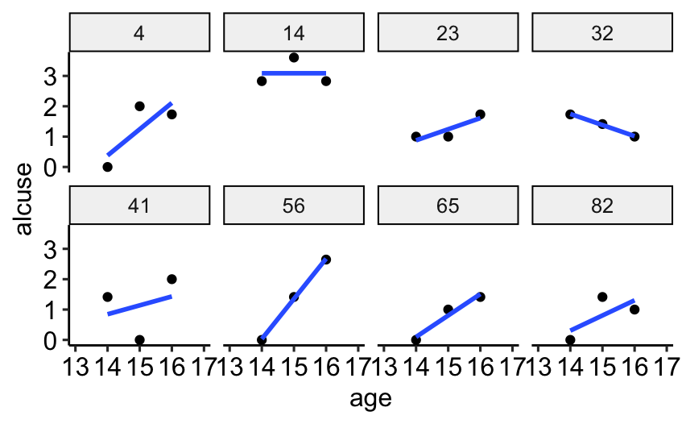

```r
# figure 4.1
alcohol1_pp %>%
  filter(id %in% c(4, 14, 23, 32, 41, 56, 65, 82)) %>%
  ggplot(., aes(x = age, y = alcuse)) +
  facet_wrap(~ id, ncol = 4) +
  geom_point() +
  geom_smooth(method = "lm", se = FALSE) +
  scale_x_continuous(limits = c(13, 17)) +
  ggpubr::theme_pubr()
```

We fit the 1-level model:

$$\text{alcuse}_{ij} = \pi_{0i} + \pi_{1i}TIME_{ij} + \epsilon_{ij}$$

- $\pi_{0i}$ represents individual *i*’s true initial status, the value of the outcome when $TIME_{ij}$ = 0.
- $\pi_{1i}$ represents individual *i*’s true rate of change during the period under study.
- $\epsilon_{ij}$ represents that portion of individual *i*’s outcome that is unpredicted on occasion *j*

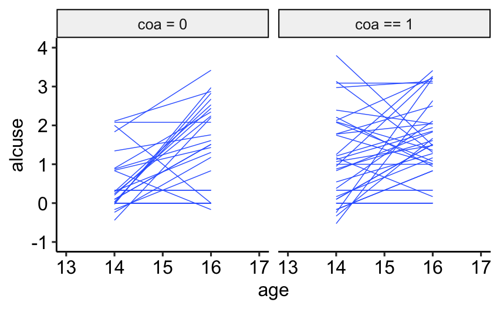

```r
set.seed(4)

alcohol1_pp %>%
  group_by(id) %>%
  nest() %>%
  sample_n(size = 32, replace = TRUE) %>%
  unnest(data) %>%
  mutate(coa = ifelse(coa == 0, "coa = 0", "coa == 1")) %>%
  ggplot(aes(x = age, y = alcuse, group = id)) +
  facet_wrap(~ coa) +
  stat_smooth(method = "lm", se = FALSE, size = 1/4) +
  coord_cartesian(xlim = c(13, 17), ylim = c(-1, 4)) +
  ggpubr::theme_pubr()
```

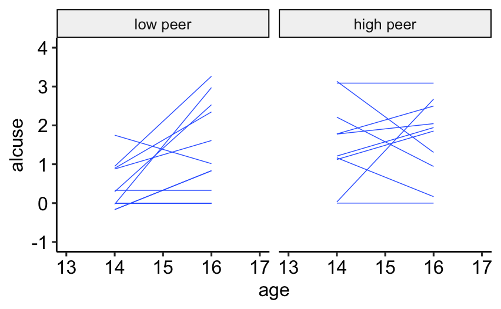

```r
set.seed(4)

alcohol1_pp %>%
  group_by(id) %>%
  nest() %>%
  ungroup() %>%
  sample_n(size = 32, replace = T) %>%
  unnest(data) %>%
  mutate(hp = ifelse(peer < mean(peer), "low peer", "high peer")) %>%
  mutate(hp = factor(hp, levels = c("low peer", "high peer"))) %>%

  ggplot(aes(x = age, y = alcuse, group = id)) +
  stat_smooth(method = "lm", se = F, size = 1/4) +
  coord_cartesian(xlim = c(13, 17),
                  ylim = c(-1, 4)) +
  ggpubr::theme_pubr() +
  facet_wrap(~ hp)
```

We now posit a level-2 submodel for interindividual differences in change:
$$\begin{aligned}
\pi_{0i} &= \gamma_{00} + \gamma_{01} \text{COA}_i + \epsilon_{0i} \\
\pi_{1i} &= \gamma_{10} + \gamma_{11} \text{COA}_i + \epsilon_{1i} \\
\end{aligned}$$

- $\gamma_{00}$ and $\gamma_{10}$ are the level-2 intercepts and represent the population average initial status and rate of change for a child of a non-alcoholic (COA = 0).
- $\gamma_{01}$ and $\gamma_{11}$ are the level-2 slopes and represent the effect of COA on the change trajectories for initial status and rates of change for children of alcoholics.

# The Composite Specification of the Multilevel Model for Change

The composite model collapses these submodels into a single specification.

This simplifies to:

$$Y_{ij} = [\gamma_{00} + \gamma_{10}TIME_{ij} + \gamma_{01}COA_i + \gamma_{11}(COA_{i} \times TIME_{ij})] + [\epsilon_{0i} + \epsilon_{1i}TIME_{ij} + \epsilon_{ij}]$$

# First Steps: Fitting Two Unconditional Multilevel Models for Change

First you should fit the unconditional means model and the unconditional growth model. These models allow you to examine variation first across people without regard to time, and second across both people and time. The results of these models will allow you to establish whether there is systematic variation in your outcome that is worth exploring, and where that variation resides (within or between people).

## The Unconditional Means Model

```r
library(brms)
library(cmdstanr)
fit4.1 <- brm(data = alcohol1_pp,
              family = gaussian,
              alcuse ~ 1 + (1 | id),
              prior = c(prior(student_t(3, 1, 10), class = Intercept),
                        prior(student_t(3, 0, 10), class = sd),
                        prior(student_t(3, 0, 10), class = sigma)),
              iter = 2000, warmup = 1000, chains = 4, cores = 4,
              backend = "cmdstan")
```

[output not shown]

[output cut: 11 more lines]

[output not shown]

[output not shown]

[output cut: 43 more lines]

[output not shown]

```r
print(fit4.1)
```

```
 Family: gaussian
  Links: mu = identity; sigma = identity
Formula: alcuse ~ 1 + (1 | id)
   Data: alcohol1_pp (Number of observations: 246)
Samples: 4 chains, each with iter = 2000; warmup = 1000; thin = 1;
         total post-warmup samples = 4000

Group-Level Effects:
~id (Number of levels: 82)
              Estimate Est.Error l-95% CI u-95% CI Rhat Bulk_ESS Tail_ESS
sd(Intercept)     0.77      0.08     0.62     0.95 1.00     1373     2378

Population-Level Effects:
          Estimate Est.Error l-95% CI u-95% CI Rhat Bulk_ESS Tail_ESS
Intercept     0.92      0.10     0.72     1.12 1.00     2169     2725

Family Specific Parameters:
      Estimate Est.Error l-95% CI u-95% CI Rhat Bulk_ESS Tail_ESS
sigma     0.76      0.04     0.68     0.84 1.00     3273     3272

Samples were drawn using sample(hmc). For each parameter, Bulk_ESS
and Tail_ESS are effective sample size measures, and Rhat is the potential
scale reduction factor on split chains (at convergence, Rhat = 1).
```

The intraclass correlation coefficient describes the proportion of the total outcome variation that lies “between” people.

```r
library(bayestestR)
library(performance)
icc(fit4.1)
```

```
# Intraclass Correlation Coefficient

     Adjusted ICC: 0.508
  Conditional ICC: 0.508
```

This means that half of the variation in alcohol use is attributable to differences between adolescents.

## The Unconditional Growth Model

The next step is the introduction of predictor TIME into the level-1 submodel.

```r
fit4.2 <- brm(data = alcohol1_pp,
              family = gaussian,
              alcuse ~ 0 + Intercept + age_14 + (1 + age_14 | id),
              prior = c(prior(student_t(3, 0, 10), class = sd),
                        prior(student_t(3, 0, 10), class = sigma),
                        prior(lkj(1), class = cor)),
              iter = 2000, warmup = 1000, chains = 4, cores = 4,
              backend = "cmdstan")
```

[output not shown]

[output cut: 25 more lines]

[output not shown]

[output not shown]

[output cut: 42 more lines]

[output not shown]

```r
print(fit4.2)
```

```
 Family: gaussian
  Links: mu = identity; sigma = identity
Formula: alcuse ~ 0 + Intercept + age_14 + (1 + age_14 | id)
   Data: alcohol1_pp (Number of observations: 246)
Samples: 4 chains, each with iter = 2000; warmup = 1000; thin = 1;
         total post-warmup samples = 4000

Group-Level Effects:
~id (Number of levels: 82)
                      Estimate Est.Error l-95% CI u-95% CI Rhat Bulk_ESS Tail_ESS
sd(Intercept)             0.79      0.10     0.59     1.00 1.00     1118     1711
sd(age_14)                0.37      0.09     0.17     0.53 1.01      545      720
cor(Intercept,age_14)    -0.13      0.25    -0.51     0.47 1.00      920     1009

Population-Level Effects:
          Estimate Est.Error l-95% CI u-95% CI Rhat Bulk_ESS Tail_ESS
Intercept     0.65      0.11     0.43     0.86 1.00     1938     2257
age_14        0.27      0.06     0.15     0.40 1.00     3326     2641

Family Specific Parameters:
      Estimate Est.Error l-95% CI u-95% CI Rhat Bulk_ESS Tail_ESS
sigma     0.61      0.05     0.52     0.71 1.01      651     1388

Samples were drawn using sample(hmc). For each parameter, Bulk_ESS
and Tail_ESS are effective sample size measures, and Rhat is the potential
scale reduction factor on split chains (at convergence, Rhat = 1).
```

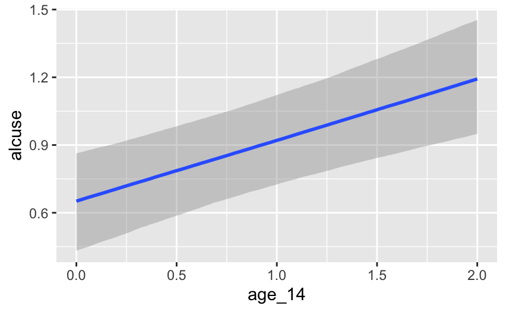

```r
conditional_effects(fit4.2)
```

# Practical Data Analytic Strategies for Model Building

## Interpreting Fitted Models

### Model C: The Uncontrolled Effects of COA

```r
fit4.3 <- brm(alcuse ~ 0 + Intercept + age_14 + coa + age_14:coa +
                (1 + age_14 | id),
              family = gaussian,
              prior = c(prior(student_t(3, 0, 10), class = sd),
                        prior(student_t(3, 0, 10), class = sigma),
                        prior(lkj(1), class = cor)),
              data = alcohol1_pp,
              cores = 4,
              backend = "cmdstan")
```

[output not shown]

[output cut: 24 more lines]

[output not shown]

[output not shown]

[output cut: 43 more lines]

[output not shown]

```r
print(fit4.3)
```

```
 Family: gaussian
  Links: mu = identity; sigma = identity
Formula: alcuse ~ 0 + Intercept + age_14 + coa + age_14:coa + (1 + age_14 | id)
   Data: alcohol1_pp (Number of observations: 246)
Samples: 4 chains, each with iter = 2000; warmup = 1000; thin = 1;
         total post-warmup samples = 4000

Group-Level Effects:
~id (Number of levels: 82)
                      Estimate Est.Error l-95% CI u-95% CI Rhat Bulk_ESS Tail_ESS
sd(Intercept)             0.70      0.10     0.51     0.90 1.00      928     1409
sd(age_14)                0.37      0.09     0.16     0.53 1.01      389      546
cor(Intercept,age_14)    -0.11      0.27    -0.51     0.62 1.01      683      594

Population-Level Effects:
           Estimate Est.Error l-95% CI u-95% CI Rhat Bulk_ESS Tail_ESS
Intercept      0.31      0.13     0.06     0.58 1.00     2073     2580
age_14         0.30      0.08     0.13     0.46 1.00     3026     2938
coa            0.74      0.20     0.35     1.13 1.00     2166     2592
age_14:coa    -0.05      0.13    -0.31     0.21 1.00     2981     2894

Family Specific Parameters:
      Estimate Est.Error l-95% CI u-95% CI Rhat Bulk_ESS Tail_ESS
sigma     0.61      0.05     0.52     0.72 1.01      534     1145

Samples were drawn using sample(hmc). For each parameter, Bulk_ESS
and Tail_ESS are effective sample size measures, and Rhat is the potential
scale reduction factor on split chains (at convergence, Rhat = 1).
```

```r
library(lme4)
fit4.3.fq <- lmer(alcuse ~ age_14 + coa + age_14:coa + (1 + age_14 | id),
                  data = alcohol1_pp)
summary(fit4.3.fq)
```

```
Linear mixed model fit by REML ['lmerMod']
Formula: alcuse ~ age_14 + coa + age_14:coa + (1 + age_14 | id)
   Data: alcohol1_pp

REML criterion at convergence: 631.9

Scaled residuals:
    Min      1Q  Median      3Q     Max
-2.5522 -0.3827 -0.1063  0.3585  2.3708

Random effects:
 Groups   Name        Variance Std.Dev. Corr
 id       (Intercept) 0.5068   0.7119
          age_14      0.1586   0.3982   -0.23
 Residual             0.3373   0.5808
Number of obs: 246, groups:  id, 82

Fixed effects:
            Estimate Std. Error t value
(Intercept)  0.31595    0.13232   2.388
age_14       0.29296    0.08527   3.435
coa          0.74321    0.19698   3.773
age_14:coa  -0.04943    0.12695  -0.389

Correlation of Fixed Effects:
           (Intr) age_14 coa
age_14     -0.460
coa        -0.672  0.309
age_14:coa  0.309 -0.672 -0.460
```

Model C includes COA as a predictor of both initial status and change. Interpretation of its four fixed effects is straightforward: (1) the estimated initial ALCUSE for the average child of non-alcoholic parents is 0.32; (2) the estimated differential in initial ALCUSE between children of alcoholic and non-alcoholic parents is 0.74; (3) the estimated rate of change in ALCUSE for an average child of non-alcoholic parents is 0.29; (4) the estimated rate of change in ALCUSE between children of alcoholic and non-alcoholic parents is -0.05.

This model provides uncontrolled answers to our research questions, suggesting that while children of alcoholic parents initially drink more than children of non-alcoholic parents, their rate of change in alcohol consumption between ages 14 and 16 does not differ.

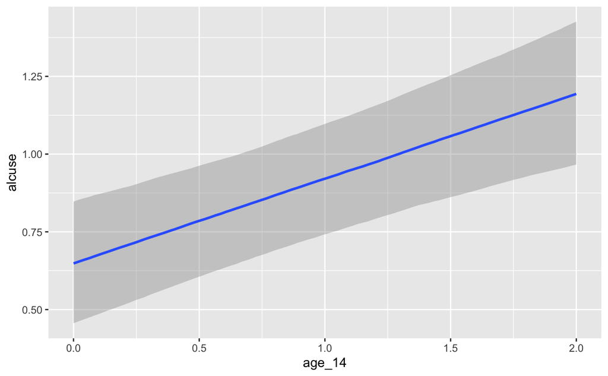

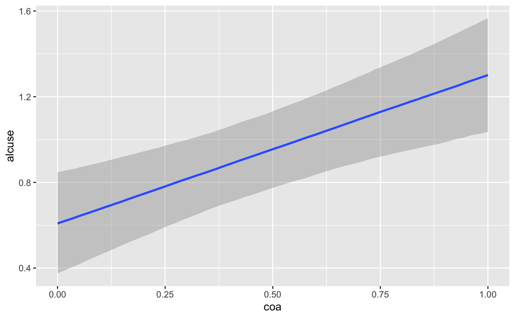

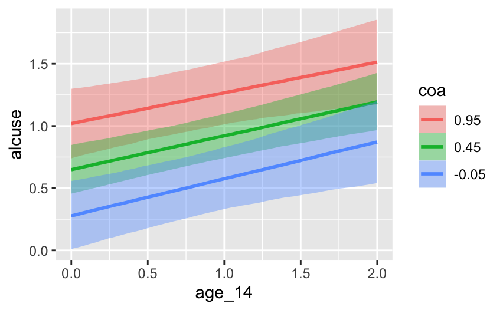

```r
conditional_effects(fit4.3)
```

Let’s recode `coa` as a factor to get a more accurate plot.

```r
fit4.4 <- update(fit4.3,
                 newdata = alcohol1_pp %>% mutate(coa = factor(coa)),
                 cores = 4,
                 backend = "cmdstan")
```

```
The desired updates require recompiling the model
```

[output not shown]

[output cut: 24 more lines]

[output not shown]

[output not shown]

[output cut: 43 more lines]

[output not shown]

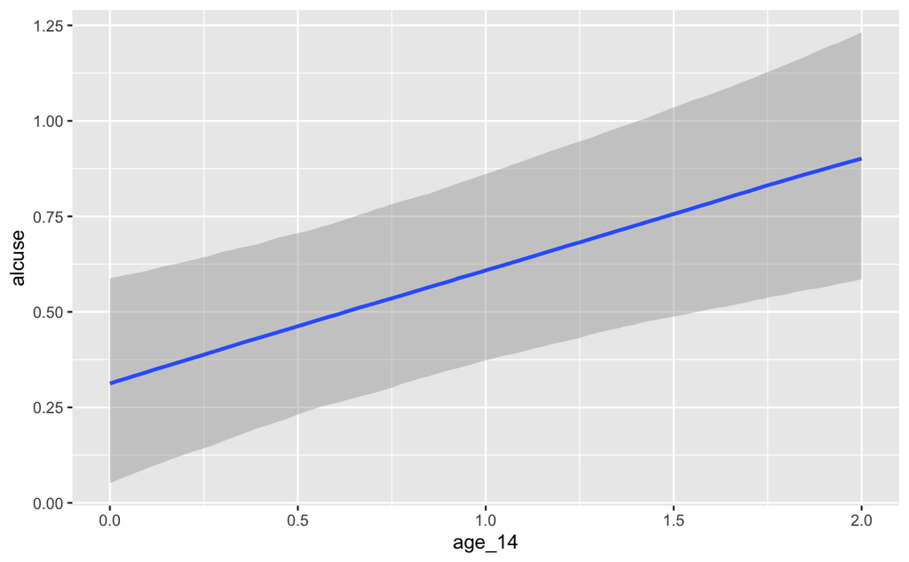

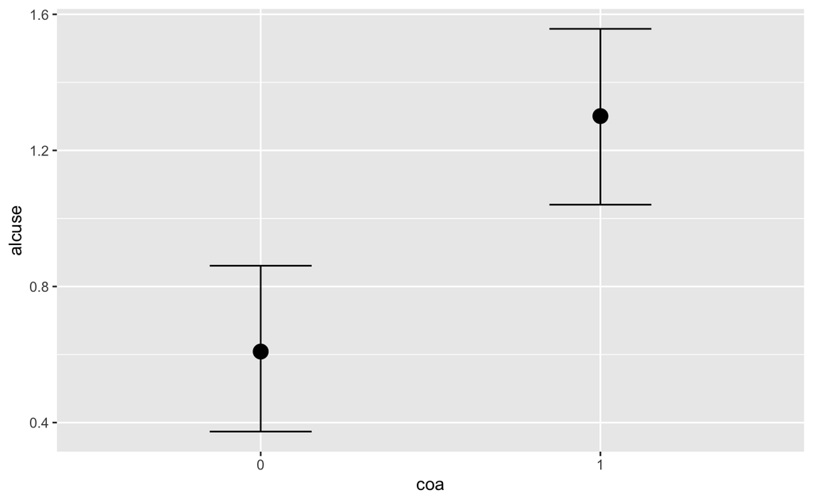

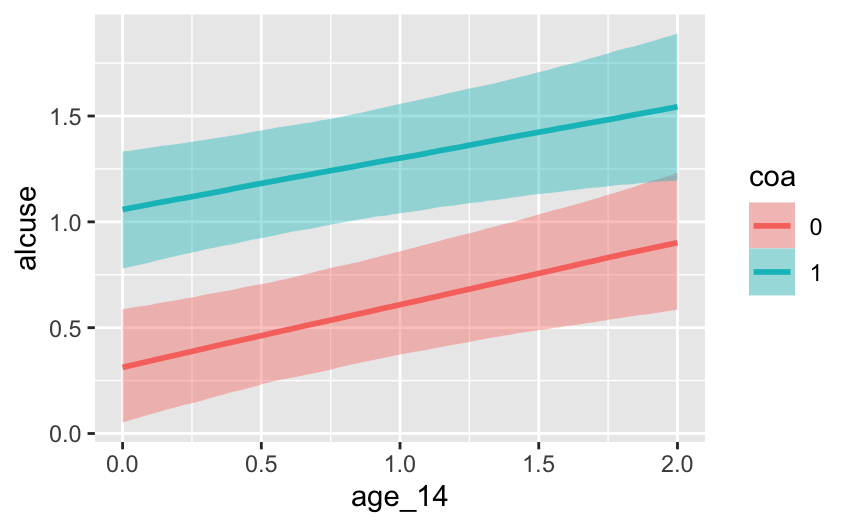

```r
conditional_effects(fit4.4)
```

### Model D: The Controlled Effects of COA

Model D estimates the effects of COA on initial status and rates fo change in ALCUSE, controlling for the effects of PEER in initial status and rate of change.

```r
fit4.5 <- brm(alcuse ~ 0 + Intercept + age_14 + coa + peer + age_14:coa +
                age_14:peer + (1 + age_14 | id),
              family = gaussian,
              prior = c(prior(student_t(3, 0, 10), class = sd),
                        prior(student_t(3, 0, 10), class = sigma),
                        prior(lkj(1), class = cor)),
              data = alcohol1_pp,
              cores = 4,
              backend = "cmdstan")
```

[output not shown]

[output cut: 22 more lines]

[output not shown]

[output not shown]

[output cut: 43 more lines]

[output not shown]

```r
print(fit4.5, digits = 3)
```

```
 Family: gaussian
  Links: mu = identity; sigma = identity
Formula: alcuse ~ 0 + Intercept + age_14 + coa + peer + age_14:coa + age_14:peer + (1 + age_14 | id)
   Data: alcohol1_pp (Number of observations: 246)
Samples: 4 chains, each with iter = 2000; warmup = 1000; thin = 1;
         total post-warmup samples = 4000

Group-Level Effects:
~id (Number of levels: 82)
                      Estimate Est.Error l-95% CI u-95% CI  Rhat Bulk_ESS Tail_ESS
sd(Intercept)            0.482     0.102    0.279    0.676 1.006      660     1229
sd(age_14)               0.363     0.080    0.207    0.517 1.015      383     1017
cor(Intercept,age_14)    0.127     0.346   -0.418    0.879 1.020      328      519

Population-Level Effects:
            Estimate Est.Error l-95% CI u-95% CI  Rhat Bulk_ESS Tail_ESS
Intercept     -0.314     0.153   -0.621   -0.018 1.002     1725     2061
age_14         0.432     0.119    0.205    0.661 1.002     1825     2852
coa            0.579     0.170    0.243    0.910 1.002     2246     2360
peer           0.693     0.114    0.467    0.910 1.001     1869     2296
age_14:coa    -0.016     0.128   -0.258    0.240 1.002     2666     3063
age_14:peer   -0.151     0.090   -0.327    0.025 1.001     1895     2517

Family Specific Parameters:
      Estimate Est.Error l-95% CI u-95% CI  Rhat Bulk_ESS Tail_ESS
sigma    0.607     0.048    0.519    0.705 1.010      479     1691

Samples were drawn using sample(hmc). For each parameter, Bulk_ESS
and Tail_ESS are effective sample size measures, and Rhat is the potential
scale reduction factor on split chains (at convergence, Rhat = 1).
```

- `coa` and `age_14:coa` describe the differential in ALCUSE between children of alcoholic and non-alcoholic parents controlling for the effects of PEER.
- `peer` and `age_14:peer` describe the differential in ALCUSE for a one-unit difference in PEER controlling for the effect of COA.

### Model E: A Tentative “Final Model” for the Controlled Effects of COA

Model E includes PEER as a predictor of both initial status and change but COA as a predictor of only initial status.

```r
fit4.6 <- brm(alcuse ~ 0 + Intercept + age_14 + coa + peer + age_14:peer +
                (1 + age_14 | id),
              family = gaussian,
              prior = c(prior(student_t(3, 0, 10), class = sd),
                        prior(student_t(3, 0, 10), class = sigma),
                        prior(lkj(1), class = cor)),
              data = alcohol1_pp,
              cores = 4,
              backend = "cmdstan")
print(fit4.6, digits = 3)
```

[output not shown]

Controlling for the effects of PEER, the estimated differential in initial ALCUSE between children of alcoholic and non-alcoholic parents is $0.57$ and controlling for the effect of parental alcoholism, for each 1-point difference in PEER: the average initial ALCUSE is $0.70$ higher and the average rate of change in ALCUSE is $-0.15$ lower. We conclude that children of alcoholic parents drink more alcohol initially than children of non-alcoholic parents but their rate of change in consumption between ages 14 and 16 is no different. We also conclude that PEER is positively associated with early consumption but negatively associated with the rate of change in consumption. 14-year-old’s whose friends drink more tend to drink more at that age, but they have a slower rate of increase in consumption over time.

## Displaying Prototypical Change Trajectories

Compute the fitted values for each group of COA:

```r
post <- posterior_samples(fit4.3)

post %>%
  select(starts_with("b_")) %>%
  head()
```

|  | b_Intercept | b_age_14 | b_coa | b_age_14:coa |
| --- | --- | --- | --- | --- |
| 1 | 0.0451145 | 0.309477 | 0.935502 | -0.032915500 |
| 2 | 0.4351150 | 0.379420 | 0.352472 | 0.083394600 |
| 3 | 0.3863770 | 0.285442 | 0.421422 | 0.081620400 |
| 4 | 0.6220110 | 0.174222 | 0.464206 | 0.051617800 |
| 5 | 0.5348630 | 0.168941 | 0.680370 | 0.000474246 |
| 6 | 0.4562950 | 0.330292 | 0.595675 | -0.048381400 |

```r
post %>%
  select(starts_with("b_")) %>%
  transmute(pi_0_coa0 = b_Intercept + b_coa * 0,
            pi_1_coa0 = b_age_14 + `b_age_14:coa` * 0,
            pi_0_coa1 = b_Intercept + b_coa * 1,
            pi_1_coa1 = b_age_14 + `b_age_14:coa` * 1) %>%
  pivot_longer(everything()) %>%
  group_by(name) %>%
  summarise(posterior_mean = mean(value) %>% round(digits = 3))
```

|  | name | posterior_mean |
| --- | --- | --- |
| 1 | pi_0_coa0 | 0.313 |
| 2 | pi_0_coa1 | 1.056 |
| 3 | pi_1_coa0 | 0.295 |
| 4 | pi_1_coa1 | 0.245 |

```r
post %>%
  select(starts_with("b_")) %>%
  mutate(y = b_Intercept + b_coa * 1 + b_age_14 * 0 + `b_age_14:coa` * 0 * 1) %>%
  head()
```

|  | b_Intercept | b_age_14 | b_coa | b_age_14:coa | y |
| --- | --- | --- | --- | --- | --- |
| 1 | 0.0451145 | 0.309477 | 0.935502 | -0.032915500 | 0.9806165 |
| 2 | 0.4351150 | 0.379420 | 0.352472 | 0.083394600 | 0.7875870 |
| 3 | 0.3863770 | 0.285442 | 0.421422 | 0.081620400 | 0.8077990 |
| 4 | 0.6220110 | 0.174222 | 0.464206 | 0.051617800 | 1.0862170 |
| 5 | 0.5348630 | 0.168941 | 0.680370 | 0.000474246 | 1.2152330 |
| 6 | 0.4562950 | 0.330292 | 0.595675 | -0.048381400 | 1.0519700 |

```r
post %>%
  select(starts_with("b_")) %>%
  mutate(y = b_Intercept + b_coa * 1 + b_age_14 * 0 + `b_age_14:coa` * 0 * 1) %>%
  summarise(pi_0_coa1 = mean(y))
```

| pi_0_coa1 |
| --- |
| 1.05558 |

Better to work with prototypical values of predictors rather than getting a fitted function for each predictor. Prototypical values can be selected by these strategies:

- Choose substantively interesting values.
- Use a range of percentiles.
- Use the sample mean $\pm 0.5$ (or 1) standard deviation.
- Use the sample mean.

We can computed the fitted values with the `fitted()` function in `brms`.

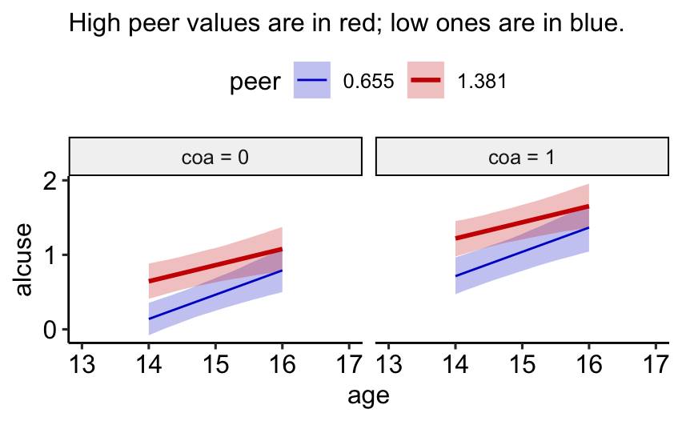

## Recentering Predictors to Improve Interpretation